# Sandbox study Simon

Kristian Tempelmans Plat & Simon Brett

5 March 2018

# LMM before outlier removal

Conclusion: no effects whatsoever

```r
simondata_before_removal = simondata

model_before=lmer(Bias~FB..1..vs.MC.2.*ConRew
            +Age
            +Gender
            +(1+FB..1..vs.MC.2.|ConRew)
            +(1+FB..1..vs.MC.2.|Participant),simondata_before_removal,REML=FALSE)

summary(model_before)
```

```
## Linear mixed model fit by maximum likelihood t-tests use Satterthwaite
##   approximations to degrees of freedom [lmerMod]
## Formula:
## Bias ~ FB..1..vs.MC.2. * ConRew + Age + Gender + (1 + FB..1..vs.MC.2. |
##     ConRew) + (1 + FB..1..vs.MC.2. | Participant)
##    Data: simondata_before_removal
##
##      AIC      BIC   logLik deviance df.resid
##  -1076.9  -1015.8    551.5  -1102.9      803
##
## Scaled residuals:
##     Min      1Q  Median      3Q     Max
## -2.0441 -0.4613 -0.1237  0.1713  5.5714
##
## Random effects:
##  Groups      Name            Variance  Std.Dev.  Corr
##  Participant (Intercept)     1.394e-04 1.181e-02
##              FB..1..vs.MC.2. 8.290e-05 9.105e-03 1.00
##  ConRew      (Intercept)     0.000e+00 0.000e+00
##              FB..1..vs.MC.2. 1.952e-15 4.418e-08  NaN
##  Residual                    1.464e-02 1.210e-01
## Number of obs: 816, groups:  Participant, 51; ConRew, 2
##
## Fixed effects:
##                          Estimate Std. Error         df t value Pr(>|t|)
## (Intercept)            -1.338e-02  6.034e-02  1.844e+02  -0.222    0.825
## FB..1..vs.MC.2.        -2.069e-02  2.682e-02  7.622e+02  -0.771    0.441
## ConRew                 -2.451e-04  2.679e-02  7.647e+02  -0.009    0.993
## Age                     1.438e-03  1.455e-03  5.170e+01   0.988    0.328
## Gender                  1.125e-02  1.409e-02  5.170e+01   0.798    0.428
## FB..1..vs.MC.2.:ConRew  6.422e-03  1.694e-02  7.647e+02   0.379    0.705
##
## Correlation of Fixed Effects:
##                (Intr) FB..1..v.MC.2. ConRew Age    Gender
## FB..1..v.MC.2. -0.664
## ConRew         -0.666  0.899
## Age            -0.578  0.000          0.000
## Gender         -0.508  0.000          0.000  0.172
## FB..1...MC.2.:  0.632 -0.948         -0.949  0.000  0.000
```

```r
     # Conclusion: no effects whatsoever
```

# Outlier removal for FB and MC separately

This approach excludes identified as outliers (M +- 3 SD ) within condition (FB / MC)

17 FB trials are removed this way

10 MC trials are removed this way

Note that more FB trials are removed than MC trials.

As outliers are all in the expected direction (but just extreme), we are at risk at handicapping ourselves.

But, as we see later, effects become significant, probably because of drastically reduced variance.

```r
m_bias_FB = mean(simondata$Bias[simondata$FBMem == "FB"])
sd_bias_FB = sd(simondata$Bias[simondata$FBMem == "FB"])

hi_FB = m_bias_FB + 3 * sd_bias_FB
lo_FB = m_bias_FB - 3 * sd_bias_FB

m_bias_Mem = mean(simondata$Bias[simondata$FBMem == "Mem"])
sd_bias_Mem = sd(simondata$Bias[simondata$FBMem == "Mem"])

hi_Mem = m_bias_Mem + 3 * sd_bias_Mem
lo_Mem = m_bias_Mem - 3 * sd_bias_Mem



simondata_FB = simondata[simondata$FBMem == "FB",]
simondata_Mem = simondata[simondata$FBMem == "Mem",]

simondata_FB_removed = simondata_FB[simondata_FB$Bias > hi_FB,]
simondata_FB = simondata_FB[simondata_FB$Bias < hi_FB,]
simondata_Mem_removed = simondata_Mem[simondata_Mem$Bias > hi_Mem,]
simondata_Mem = simondata_Mem[simondata_Mem$Bias < hi_Mem,]

# See which trials/scenarios are most frequently outliers
sort(simondata_FB_removed$TrialNumber)
```

```
##  [1]  2  2  2  2  8  8  8  9 11 11 11 11 14 14 16 16 16
```

```r
sort(simondata_Mem_removed$TrialNumber)
```

```
##  [1]  3  3  3  3  4 12 12 13 13 13
```

```r
simondata_new = rbind(simondata_FB,simondata_Mem)
simondata = simondata_new

# Note: participant 34 had 5 / 16 outliers!
```

# Linear mixed models

After outlier removal:

Main effect of condition

Main effect of reward

```r
# Model 1: same as Simon's model 3 but WITH interaction
#   includes
# - main effects of Condition and Reward
# - interaction between Condition and Reward
# - control variables Age and Gender
# - random effect for Condition|Participant

model1=lmer(Bias~FB..1..vs.MC.2.*ConRew
            +Age
            +Gender
            +(1+FB..1..vs.MC.2.|Participant),simondata,REML=FALSE)

summary(model1)
```

```
## Linear mixed model fit by maximum likelihood t-tests use Satterthwaite
##   approximations to degrees of freedom [lmerMod]
## Formula:
## Bias ~ FB..1..vs.MC.2. * ConRew + Age + Gender + (1 + FB..1..vs.MC.2. |
##     Participant)
##    Data: simondata
##
##      AIC      BIC   logLik deviance df.resid
##  -1747.1  -1700.4    883.5  -1767.1      779
##
## Scaled residuals:
##     Min      1Q  Median      3Q     Max
## -2.9127 -0.5025 -0.0500  0.3602  4.8581
##
## Random effects:
##  Groups      Name            Variance  Std.Dev. Corr
##  Participant (Intercept)     4.483e-04 0.021173
##              FB..1..vs.MC.2. 5.751e-06 0.002398 -1.00
##  Residual                    6.003e-03 0.077481
## Number of obs: 789, groups:  Participant, 51
##
## Fixed effects:
##                          Estimate Std. Error         df t value Pr(>|t|)
## (Intercept)             5.019e-02  4.003e-02  1.732e+02   1.254 0.211527
## FB..1..vs.MC.2.        -5.693e-02  1.744e-02  7.392e+02  -3.265 0.001146
## ConRew                 -5.097e-02  1.750e-02  7.391e+02  -2.912 0.003699
## Age                     1.626e-03  9.758e-04  5.100e+01   1.666 0.101775
## Gender                 -1.480e-03  9.403e-03  5.020e+01  -0.157 0.875535
## FB..1..vs.MC.2.:ConRew  3.677e-02  1.104e-02  7.387e+02   3.331 0.000908
##
## (Intercept)
## FB..1..vs.MC.2.        **
## ConRew                 **
## Age
## Gender
## FB..1..vs.MC.2.:ConRew ***
## ---
## Signif. codes:  0 '***' 0.001 '**' 0.01 '*' 0.05 '.' 0.1 ' ' 1
##
## Correlation of Fixed Effects:
##                (Intr) FB..1..v.MC.2. ConRew Age    Gender
## FB..1..v.MC.2. -0.659
## ConRew         -0.656  0.899
## Age            -0.586  0.003          0.002
## Gender         -0.516  0.006          0.006  0.173
## FB..1...MC.2.:  0.624 -0.948         -0.949 -0.003 -0.006
```

```r
    # Model 1 conclusion:
      # Condition = Sig; FB > MC [bias]
      # Reward    = Sig; Pos > Neg
      # Con*Rew   = Sig; Bias is higher for Negative



# With outliers

model1_o=lmer(Bias~FB..1..vs.MC.2.*ConRew
            +Age
            +Gender
            +(1+FB..1..vs.MC.2.|Participant),simondata_before_removal,REML=FALSE)

summary(model1_o)
```

```
## Linear mixed model fit by maximum likelihood t-tests use Satterthwaite
##   approximations to degrees of freedom [lmerMod]
## Formula:
## Bias ~ FB..1..vs.MC.2. * ConRew + Age + Gender + (1 + FB..1..vs.MC.2. |
##     Participant)
##    Data: simondata_before_removal
##
##      AIC      BIC   logLik deviance df.resid
##  -1082.9  -1035.9    551.5  -1102.9      806
##
## Scaled residuals:
##     Min      1Q  Median      3Q     Max
## -2.0441 -0.4613 -0.1237  0.1713  5.5714
##
## Random effects:
##  Groups      Name            Variance  Std.Dev. Corr
##  Participant (Intercept)     0.0001394 0.011807
##              FB..1..vs.MC.2. 0.0000829 0.009105 1.00
##  Residual                    0.0146426 0.121007
## Number of obs: 816, groups:  Participant, 51
##
## Fixed effects:
##                          Estimate Std. Error         df t value Pr(>|t|)
## (Intercept)            -1.338e-02  6.034e-02  1.844e+02  -0.222    0.825
## FB..1..vs.MC.2.        -2.069e-02  2.682e-02  7.622e+02  -0.771    0.441
## ConRew                 -2.451e-04  2.679e-02  7.647e+02  -0.009    0.993
## Age                     1.438e-03  1.455e-03  5.170e+01   0.988    0.328
## Gender                  1.125e-02  1.409e-02  5.170e+01   0.798    0.428
## FB..1..vs.MC.2.:ConRew  6.422e-03  1.694e-02  7.647e+02   0.379    0.705
##
## Correlation of Fixed Effects:
##                (Intr) FB..1..v.MC.2. ConRew Age    Gender
## FB..1..v.MC.2. -0.664
## ConRew         -0.666  0.899
## Age            -0.578  0.000          0.000
## Gender         -0.508  0.000          0.000  0.172
## FB..1...MC.2.:  0.632 -0.948         -0.949  0.000  0.000
```

```r
# Model 2 [EXACTLY THE SAME AS SIMON'S MODEL 3]
#   includes
# - main effects of Condition and Reward
# - interaction between Condition and Reward
# - control variables Age and Gender
# - random effect for Condition|Participant
# - random effect for Condition|Reward (but should this not be taken away, as Reward is a within-subject variable?)
    # - random effects based on Simon's Model1

model2=lmer(Bias~FB..1..vs.MC.2.*ConRew
            +Age
            +Gender
            +(1+FB..1..vs.MC.2.|ConRew)
            +(1+FB..1..vs.MC.2.|Participant),simondata,REML=FALSE)

summary(model2)
```

```
## Linear mixed model fit by maximum likelihood t-tests use Satterthwaite
##   approximations to degrees of freedom [lmerMod]
## Formula:
## Bias ~ FB..1..vs.MC.2. * ConRew + Age + Gender + (1 + FB..1..vs.MC.2. |
##     ConRew) + (1 + FB..1..vs.MC.2. | Participant)
##    Data: simondata
##
##      AIC      BIC   logLik deviance df.resid
##  -1741.1  -1680.3    883.5  -1767.1      776
##
## Scaled residuals:
##     Min      1Q  Median      3Q     Max
## -2.9127 -0.5025 -0.0500  0.3602  4.8581
##
## Random effects:
##  Groups      Name            Variance  Std.Dev.  Corr
##  Participant (Intercept)     4.483e-04 2.117e-02
##              FB..1..vs.MC.2. 5.752e-06 2.398e-03 -1.00
##  ConRew      (Intercept)     0.000e+00 0.000e+00
##              FB..1..vs.MC.2. 7.955e-19 8.919e-10  NaN
##  Residual                    6.003e-03 7.748e-02
## Number of obs: 789, groups:  Participant, 51; ConRew, 2
##
## Fixed effects:
##                          Estimate Std. Error         df t value Pr(>|t|)
## (Intercept)             5.019e-02  4.003e-02  1.732e+02   1.254 0.211527
## FB..1..vs.MC.2.        -5.693e-02  1.744e-02  7.392e+02  -3.265 0.001146
## ConRew                 -5.097e-02  1.750e-02  7.391e+02  -2.912 0.003699
## Age                     1.626e-03  9.758e-04  5.100e+01   1.666 0.101775
## Gender                 -1.480e-03  9.403e-03  5.020e+01  -0.157 0.875536
## FB..1..vs.MC.2.:ConRew  3.677e-02  1.104e-02  7.387e+02   3.331 0.000908
##
## (Intercept)
## FB..1..vs.MC.2.        **
## ConRew                 **
## Age
## Gender
## FB..1..vs.MC.2.:ConRew ***
## ---
## Signif. codes:  0 '***' 0.001 '**' 0.01 '*' 0.05 '.' 0.1 ' ' 1
##
## Correlation of Fixed Effects:
##                (Intr) FB..1..v.MC.2. ConRew Age    Gender
## FB..1..v.MC.2. -0.659
## ConRew         -0.656  0.899
## Age            -0.586  0.003          0.002
## Gender         -0.516  0.006          0.006  0.173
## FB..1...MC.2.:  0.624 -0.948         -0.949 -0.003 -0.006
```

```r
model2_o=lmer(Bias~FB..1..vs.MC.2.*ConRew
            +Age
            +Gender
            +(1+FB..1..vs.MC.2.|ConRew)
            +(1+FB..1..vs.MC.2.|Participant),simondata_before_removal,REML=FALSE)

summary(model2_o)
```

```
## Linear mixed model fit by maximum likelihood t-tests use Satterthwaite
##   approximations to degrees of freedom [lmerMod]
## Formula:
## Bias ~ FB..1..vs.MC.2. * ConRew + Age + Gender + (1 + FB..1..vs.MC.2. |
##     ConRew) + (1 + FB..1..vs.MC.2. | Participant)
##    Data: simondata_before_removal
##
##      AIC      BIC   logLik deviance df.resid
##  -1076.9  -1015.8    551.5  -1102.9      803
##
## Scaled residuals:
##     Min      1Q  Median      3Q     Max
## -2.0441 -0.4613 -0.1237  0.1713  5.5714
##
## Random effects:
##  Groups      Name            Variance  Std.Dev.  Corr
##  Participant (Intercept)     1.394e-04 1.181e-02
##              FB..1..vs.MC.2. 8.290e-05 9.105e-03 1.00
##  ConRew      (Intercept)     0.000e+00 0.000e+00
##              FB..1..vs.MC.2. 1.952e-15 4.418e-08  NaN
##  Residual                    1.464e-02 1.210e-01
## Number of obs: 816, groups:  Participant, 51; ConRew, 2
##
## Fixed effects:
##                          Estimate Std. Error         df t value Pr(>|t|)
## (Intercept)            -1.338e-02  6.034e-02  1.844e+02  -0.222    0.825
## FB..1..vs.MC.2.        -2.069e-02  2.682e-02  7.622e+02  -0.771    0.441
## ConRew                 -2.451e-04  2.679e-02  7.647e+02  -0.009    0.993
## Age                     1.438e-03  1.455e-03  5.170e+01   0.988    0.328
## Gender                  1.125e-02  1.409e-02  5.170e+01   0.798    0.428
## FB..1..vs.MC.2.:ConRew  6.422e-03  1.694e-02  7.647e+02   0.379    0.705
##
## Correlation of Fixed Effects:
##                (Intr) FB..1..v.MC.2. ConRew Age    Gender
## FB..1..v.MC.2. -0.664
## ConRew         -0.666  0.899
## Age            -0.578  0.000          0.000
## Gender         -0.508  0.000          0.000  0.172
## FB..1...MC.2.:  0.632 -0.948         -0.949  0.000  0.000
```

```r
# Model 3 [Simon's model 3 but with random effects from model 2]

model3 = lmer(Bias~ConRew*FB..1..vs.MC.2.+Age+Gender+(
  1+ConRew|Participant) + (1+ConRew|FB..1..vs.MC.2.),simondata,REML = FALSE)

summary(model3)
```

```
## Linear mixed model fit by maximum likelihood t-tests use Satterthwaite
##   approximations to degrees of freedom [lmerMod]
## Formula: Bias ~ ConRew * FB..1..vs.MC.2. + Age + Gender + (1 + ConRew |
##     Participant) + (1 + ConRew | FB..1..vs.MC.2.)
##    Data: simondata
##
##      AIC      BIC   logLik deviance df.resid
##  -1743.3  -1682.6    884.6  -1769.3      776
##
## Scaled residuals:
##     Min      1Q  Median      3Q     Max
## -3.0355 -0.5237 -0.0577  0.3889  4.8356
##
## Random effects:
##  Groups          Name        Variance  Std.Dev.  Corr
##  Participant     (Intercept) 1.155e-03 3.399e-02
##                  ConRew      1.170e-04 1.082e-02 -1.00
##  FB..1..vs.MC.2. (Intercept) 0.000e+00 0.000e+00
##                  ConRew      8.068e-18 2.840e-09  NaN
##  Residual                    5.966e-03 7.724e-02
## Number of obs: 789, groups:  Participant, 51; FB..1..vs.MC.2., 2
##
## Fixed effects:
##                          Estimate Std. Error         df t value Pr(>|t|)
## (Intercept)             4.682e-02  3.986e-02  1.896e+02   1.175 0.241663
## ConRew                 -5.092e-02  1.751e-02  7.356e+02  -2.907 0.003755
## FB..1..vs.MC.2.        -5.691e-02  1.738e-02  7.401e+02  -3.274 0.001110
## Age                     1.787e-03  9.617e-04  5.490e+01   1.858 0.068495
## Gender                 -1.453e-03  9.291e-03  5.420e+01  -0.156 0.876299
## ConRew:FB..1..vs.MC.2.  3.673e-02  1.101e-02  7.394e+02   3.337 0.000889
##
## (Intercept)
## ConRew                 **
## FB..1..vs.MC.2.        **
## Age                    .
## Gender
## ConRew:FB..1..vs.MC.2. ***
## ---
## Signif. codes:  0 '***' 0.001 '**' 0.01 '*' 0.05 '.' 0.1 ' ' 1
##
## Correlation of Fixed Effects:
##             (Intr) ConRew FB..1. Age    Gender
## ConRew      -0.665
## FB..1...MC. -0.657  0.895
## Age         -0.580  0.001  0.002
## Gender      -0.512  0.006  0.005  0.174
## CR:FB..1...  0.625 -0.945 -0.949 -0.002 -0.005
```

```r
model3_O = lmer(Bias~ConRew*FB..1..vs.MC.2.+Age+Gender+(
  1+ConRew|Participant) + (1+ConRew|FB..1..vs.MC.2.),simondata_before_removal,REML = FALSE)

summary(model3_O)
```

```
## Linear mixed model fit by maximum likelihood t-tests use Satterthwaite
##   approximations to degrees of freedom [lmerMod]
## Formula: Bias ~ ConRew * FB..1..vs.MC.2. + Age + Gender + (1 + ConRew |
##     Participant) + (1 + ConRew | FB..1..vs.MC.2.)
##    Data: simondata_before_removal
##
##      AIC      BIC   logLik deviance df.resid
##  -1079.0  -1017.8    552.5  -1105.0      803
##
## Scaled residuals:
##     Min      1Q  Median      3Q     Max
## -2.0808 -0.4699 -0.1279  0.1624  5.5626
##
## Random effects:
##  Groups          Name        Variance  Std.Dev.  Corr
##  Participant     (Intercept) 2.677e-03 5.174e-02
##                  ConRew      2.917e-04 1.708e-02 -1.00
##  FB..1..vs.MC.2. (Intercept) 2.093e-15 4.575e-08
##                  ConRew      6.160e-16 2.482e-08 -1.00
##  Residual                    1.456e-02 1.206e-01
## Number of obs: 816, groups:  Participant, 51; FB..1..vs.MC.2., 2
##
## Fixed effects:
##                          Estimate Std. Error         df t value Pr(>|t|)
## (Intercept)            -1.130e-02  6.058e-02  1.999e+02  -0.187    0.852
## ConRew                 -2.451e-04  2.682e-02  7.629e+02  -0.009    0.993
## FB..1..vs.MC.2.        -2.069e-02  2.671e-02  7.650e+02  -0.774    0.439
## Age                     1.225e-03  1.452e-03  5.710e+01   0.844    0.402
## Gender                  1.258e-02  1.406e-02  5.710e+01   0.895    0.375
## ConRew:FB..1..vs.MC.2.  6.422e-03  1.689e-02  7.650e+02   0.380    0.704
##
## Correlation of Fixed Effects:
##             (Intr) ConRew FB..1. Age    Gender
## ConRew      -0.669
## FB..1...MC. -0.661  0.896
## Age         -0.574  0.000  0.000
## Gender      -0.505  0.000  0.000  0.172
## CR:FB..1...  0.627 -0.945 -0.949  0.000  0.000
```

Conclusion for models 1-3:

Condition = Sig; FB > MC [bias]

Reward = Sig; Pos > Neg

Con*Rew = Sig; Bias is higher for Negative

Model 3: Also marginally significant effect of age

# Linear mixed models with AQ

```r
# AQ mean-centred


for (i in 1:length(simondata$AQ)){
  simondata$AQ.mc[i] = simondata$AQ[i] - AQ_means
}

for (i in 1:length(simondata_before_removal$AQ)){
  simondata_before_removal$AQ.mc[i] = simondata_before_removal$AQ[i] - AQ_means
}


# Model 4: with AQ, 1 random effect
model4=lmer(Bias~FB..1..vs.MC.2.*ConRew*AQ.mc
            +Age
            +Gender
            +(1+FB..1..vs.MC.2.|Participant),simondata,REML=FALSE)

summary(model4)
```

```
## Linear mixed model fit by maximum likelihood t-tests use Satterthwaite
##   approximations to degrees of freedom [lmerMod]
## Formula: Bias ~ FB..1..vs.MC.2. * ConRew * AQ.mc + Age + Gender + (1 +
##     FB..1..vs.MC.2. | Participant)
##    Data: simondata
##
##      AIC      BIC   logLik deviance df.resid
##  -1744.3  -1678.9    886.1  -1772.3      775
##
## Scaled residuals:
##     Min      1Q  Median      3Q     Max
## -2.9257 -0.4958 -0.0683  0.3732  4.9265
##
## Random effects:
##  Groups      Name            Variance  Std.Dev. Corr
##  Participant (Intercept)     4.226e-04 0.020558
##              FB..1..vs.MC.2. 4.421e-06 0.002103 -1.00
##  Residual                    5.966e-03 0.077243
## Number of obs: 789, groups:  Participant, 51
##
## Fixed effects:
##                                Estimate Std. Error         df t value
## (Intercept)                   5.383e-02  4.013e-02  1.702e+02   1.341
## FB..1..vs.MC.2.              -5.701e-02  1.738e-02  7.392e+02  -3.280
## ConRew                       -5.117e-02  1.745e-02  7.391e+02  -2.933
## AQ.mc                        -5.113e-03  4.108e-03  7.303e+02  -1.244
## Age                           1.441e-03  9.995e-04  5.100e+01   1.442
## Gender                       -1.253e-03  9.350e-03  5.020e+01  -0.134
## FB..1..vs.MC.2.:ConRew        3.687e-02  1.100e-02  7.387e+02   3.351
## FB..1..vs.MC.2.:AQ.mc         2.601e-03  2.580e-03  7.384e+02   1.008
## ConRew:AQ.mc                  4.481e-03  2.594e-03  7.387e+02   1.727
## FB..1..vs.MC.2.:ConRew:AQ.mc -2.227e-03  1.636e-03  7.383e+02  -1.362
##                              Pr(>|t|)
## (Intercept)                  0.181621
## FB..1..vs.MC.2.              0.001088 **
## ConRew                       0.003464 **
## AQ.mc                        0.213725
## Age                          0.155460
## Gender                       0.893958
## FB..1..vs.MC.2.:ConRew       0.000847 ***
```

[output cut: 12 more lines]

```
## Gender            -0.509  0.006          0.005  0.000  0.163
## FB..1..v.MC.2.:CR  0.621 -0.948         -0.949 -0.001 -0.003 -0.006
## FB..1...MC.2.:A   -0.003 -0.002         -0.001 -0.945  0.005  0.002
## ConRw:AQ.mc       -0.003 -0.001         -0.003 -0.942  0.003  0.004
## FB..1...MC.2.:CR:  0.002  0.002          0.003  0.895 -0.004 -0.003
##                   FB..1..v.MC.2.:CR FB..1...MC.2.:A CR:AQ.
## FB..1..v.MC.2.
## ConRew
## AQ.mc
## Age
## Gender
## FB..1..v.MC.2.:CR
## FB..1...MC.2.:A    0.002
## ConRw:AQ.mc        0.003             0.899
## FB..1...MC.2.:CR: -0.003            -0.948          -0.949
```

```r
model4_o=lmer(Bias~FB..1..vs.MC.2.*ConRew*AQ.mc
            +Age
            +Gender
            +(1+FB..1..vs.MC.2.|Participant),simondata_before_removal,REML=FALSE)

summary(model4_o)
```

```
## Linear mixed model fit by maximum likelihood t-tests use Satterthwaite
##   approximations to degrees of freedom [lmerMod]
## Formula: Bias ~ FB..1..vs.MC.2. * ConRew * AQ.mc + Age + Gender + (1 +
##     FB..1..vs.MC.2. | Participant)
##    Data: simondata_before_removal
##
##      AIC      BIC   logLik deviance df.resid
##  -1075.6  -1009.8    551.8  -1103.6      802
##
## Scaled residuals:
##     Min      1Q  Median      3Q     Max
## -2.0436 -0.4572 -0.1334  0.1714  5.6466
##
## Random effects:
##  Groups      Name            Variance  Std.Dev. Corr
##  Participant (Intercept)     1.396e-04 0.011813
##              FB..1..vs.MC.2. 8.232e-05 0.009073 1.00
##  Residual                    1.463e-02 0.120959
## Number of obs: 816, groups:  Participant, 51
##
## Fixed effects:
##                                Estimate Std. Error         df t value
## (Intercept)                  -1.108e-02  6.072e-02  1.805e+02  -0.182
## FB..1..vs.MC.2.              -2.069e-02  2.681e-02  7.623e+02  -0.772
## ConRew                       -2.451e-04  2.678e-02  7.647e+02  -0.009
## AQ.mc                        -4.586e-04  6.365e-03  7.634e+02  -0.072
## Age                           1.321e-03  1.498e-03  5.170e+01   0.882
## Gender                        1.134e-02  1.408e-02  5.170e+01   0.805
## FB..1..vs.MC.2.:ConRew        6.422e-03  1.694e-02  7.647e+02   0.379
## FB..1..vs.MC.2.:AQ.mc        -2.399e-04  4.025e-03  7.623e+02  -0.060
## ConRew:AQ.mc                  1.147e-03  4.021e-03  7.647e+02   0.285
## FB..1..vs.MC.2.:ConRew:AQ.mc -2.985e-04  2.543e-03  7.647e+02  -0.117
##                              Pr(>|t|)
## (Intercept)                     0.855
## FB..1..vs.MC.2.                 0.441
## ConRew                          0.993
## AQ.mc                           0.943
## Age                             0.382
## Gender                          0.424
## FB..1..vs.MC.2.:ConRew          0.705
```

[output cut: 10 more lines]

```
## Gender            -0.502  0.000          0.000  0.002  0.162
## FB..1..v.MC.2.:CR  0.628 -0.948         -0.949  0.000  0.000  0.000
## FB..1...MC.2.:A    0.000  0.000          0.000 -0.945  0.000  0.000
## ConRw:AQ.mc        0.000  0.000          0.000 -0.947  0.000  0.000
## FB..1...MC.2.:CR:  0.000  0.000          0.000  0.899  0.000  0.000
##                   FB..1..v.MC.2.:CR FB..1...MC.2.:A CR:AQ.
## FB..1..v.MC.2.
## ConRew
## AQ.mc
## Age
## Gender
## FB..1..v.MC.2.:CR
## FB..1...MC.2.:A    0.000
## ConRw:AQ.mc        0.000             0.899
## FB..1...MC.2.:CR:  0.000            -0.948          -0.949
```

```r
# Model 5: with AQ, 2 random effects
model5=lmer(Bias~FB..1..vs.MC.2.*ConRew*AQ.mc
            +Age
            +Gender
            +(1+FB..1..vs.MC.2.|Participant)
            +(1+ConRew|Participant),simondata,REML=FALSE)

summary(model5)
```

```
## Linear mixed model fit by maximum likelihood t-tests use Satterthwaite
##   approximations to degrees of freedom [lmerMod]
## Formula: Bias ~ FB..1..vs.MC.2. * ConRew * AQ.mc + Age + Gender + (1 +
##     FB..1..vs.MC.2. | Participant) + (1 + ConRew | Participant)
##    Data: simondata
##
##      AIC      BIC   logLik deviance df.resid
##  -1740.8  -1661.4    887.4  -1774.8      772
##
## Scaled residuals:
##     Min      1Q  Median      3Q     Max
## -3.0512 -0.5160 -0.0668  0.3867  4.8973
##
## Random effects:
##  Groups        Name            Variance  Std.Dev.  Corr
##  Participant   (Intercept)     9.749e-15 9.874e-08
##                FB..1..vs.MC.2. 9.833e-16 3.136e-08 -1.00
##  Participant.1 (Intercept)     1.204e-03 3.469e-02
##                ConRew          1.286e-04 1.134e-02 -1.00
##  Residual                      5.923e-03 7.696e-02
## Number of obs: 789, groups:  Participant, 51
##
## Fixed effects:
##                                Estimate Std. Error         df t value
## (Intercept)                    0.051711   0.039970 188.900000   1.294
## FB..1..vs.MC.2.               -0.057004   0.017321 740.200000  -3.291
## ConRew                        -0.051135   0.017457 736.100000  -2.929
## AQ.mc                         -0.005120   0.004135 720.100000  -1.238
## Age                            0.001534   0.000985  55.900000   1.558
## Gender                        -0.001121   0.009239  55.200000  -0.121
## FB..1..vs.MC.2.:ConRew         0.036835   0.010966 739.500000   3.359
## FB..1..vs.MC.2.:AQ.mc          0.002599   0.002570 738.700000   1.011
## ConRew:AQ.mc                   0.004471   0.002595 735.500000   1.723
## FB..1..vs.MC.2.:ConRew:AQ.mc  -0.002222   0.001630 738.700000  -1.364
##                              Pr(>|t|)
## (Intercept)                  0.197331
## FB..1..vs.MC.2.              0.001045 **
## ConRew                       0.003503 **
## AQ.mc                        0.216104
## Age                          0.124920
```

[output cut: 14 more lines]

```
## Gender            -0.505  0.005          0.006 -0.001  0.164
## FB..1..v.MC.2.:CR  0.621 -0.949         -0.945 -0.001 -0.003 -0.005
## FB..1...MC.2.:A   -0.003 -0.002         -0.001 -0.933  0.004  0.003
## ConRw:AQ.mc       -0.003 -0.001         -0.003 -0.945  0.003  0.005
## FB..1...MC.2.:CR:  0.002  0.002          0.003  0.886 -0.003 -0.004
##                   FB..1..v.MC.2.:CR FB..1...MC.2.:A CR:AQ.
## FB..1..v.MC.2.
## ConRew
## AQ.mc
## Age
## Gender
## FB..1..v.MC.2.:CR
## FB..1...MC.2.:A    0.002
## ConRw:AQ.mc        0.003             0.895
## FB..1...MC.2.:CR: -0.003            -0.948          -0.945
```

```r
model5_o=lmer(Bias~FB..1..vs.MC.2.*ConRew*AQ.mc
            +Age
            +Gender
            +(1+FB..1..vs.MC.2.|Participant)
            +(1+ConRew|Participant),simondata_before_removal,REML=FALSE)

summary(model5_o)
```

```
## Linear mixed model fit by maximum likelihood t-tests use Satterthwaite
##   approximations to degrees of freedom [lmerMod]
## Formula: Bias ~ FB..1..vs.MC.2. * ConRew * AQ.mc + Age + Gender + (1 +
##     FB..1..vs.MC.2. | Participant) + (1 + ConRew | Participant)
##    Data: simondata_before_removal
##
##      AIC      BIC   logLik deviance df.resid
##  -1071.7   -991.7    552.9  -1105.7      799
##
## Scaled residuals:
##     Min      1Q  Median      3Q     Max
## -2.0708 -0.4689 -0.1386  0.1678  5.6421
##
## Random effects:
##  Groups        Name            Variance  Std.Dev.  Corr
##  Participant   (Intercept)     7.614e-13 8.726e-07
##                FB..1..vs.MC.2. 8.338e-13 9.131e-07 -1.00
##  Participant.1 (Intercept)     2.696e-03 5.192e-02
##                ConRew          2.963e-04 1.721e-02 -1.00
##  Residual                      1.454e-02 1.206e-01
## Number of obs: 816, groups:  Participant, 51
##
## Fixed effects:
##                                Estimate Std. Error         df t value
## (Intercept)                  -8.382e-03  6.096e-02  1.962e+02  -0.137
## FB..1..vs.MC.2.              -2.069e-02  2.670e-02  7.650e+02  -0.775
## ConRew                       -2.451e-04  2.681e-02  7.630e+02  -0.009
## AQ.mc                        -4.186e-04  6.435e-03  7.508e+02  -0.065
## Age                           1.076e-03  1.495e-03  5.730e+01   0.720
## Gender                        1.269e-02  1.405e-02  5.730e+01   0.903
## FB..1..vs.MC.2.:ConRew        6.422e-03  1.689e-02  7.650e+02   0.380
## FB..1..vs.MC.2.:AQ.mc        -2.399e-04  4.008e-03  7.650e+02  -0.060
## ConRew:AQ.mc                  1.147e-03  4.025e-03  7.630e+02   0.285
## FB..1..vs.MC.2.:ConRew:AQ.mc -2.985e-04  2.535e-03  7.650e+02  -0.118
##                              Pr(>|t|)
## (Intercept)                     0.891
## FB..1..vs.MC.2.                 0.439
## ConRew                          0.993
## AQ.mc                           0.948
## Age                             0.475
```

[output cut: 12 more lines]

```
## Gender            -0.499  0.000          0.000  0.002  0.162
## FB..1..v.MC.2.:CR  0.623 -0.949         -0.945  0.000  0.000  0.000
## FB..1...MC.2.:A    0.000  0.000          0.000 -0.934  0.000  0.000
## ConRw:AQ.mc        0.000  0.000          0.000 -0.946  0.000  0.000
## FB..1...MC.2.:CR:  0.000  0.000          0.000  0.886  0.000  0.000
##                   FB..1..v.MC.2.:CR FB..1...MC.2.:A CR:AQ.
## FB..1..v.MC.2.
## ConRew
## AQ.mc
## Age
## Gender
## FB..1..v.MC.2.:CR
## FB..1...MC.2.:A    0.000
## ConRw:AQ.mc        0.000             0.896
## FB..1...MC.2.:CR:  0.000            -0.949          -0.945
```

AQ only visible in marginally significant interaction with Reward

# Linear mixed model with four-way interaction (Con,Rew,AQ,TrialNo)

```r
# Model 6: four-way interaction of (Rew,Con,AQ,TrialNo)
model6=lmer(Bias~FB..1..vs.MC.2.*ConRew*TrialNumber*AQ +FB..1..vs.MC.2. +ConRew
            +Age+Gender
            +(1+FB..1..vs.MC.2.|Participant),simondata,REML=FALSE)

summary(model6)
```

```
## Linear mixed model fit by maximum likelihood t-tests use Satterthwaite
##   approximations to degrees of freedom [lmerMod]
## Formula:
## Bias ~ FB..1..vs.MC.2. * ConRew * TrialNumber * AQ + FB..1..vs.MC.2. +
##     ConRew + Age + Gender + (1 + FB..1..vs.MC.2. | Participant)
##    Data: simondata
##
##      AIC      BIC   logLik deviance df.resid
##  -1751.1  -1648.3    897.5  -1795.1      767
##
## Scaled residuals:
##     Min      1Q  Median      3Q     Max
## -2.8418 -0.5340 -0.0868  0.4094  4.7627
##
## Random effects:
##  Groups      Name            Variance  Std.Dev. Corr
##  Participant (Intercept)     4.448e-04 0.021091
##              FB..1..vs.MC.2. 5.081e-06 0.002254 -1.00
##  Residual                    5.785e-03 0.076062
## Number of obs: 789, groups:  Participant, 51
##
## Fixed effects:
##                                         Estimate Std. Error         df
## (Intercept)                            3.395e-01  1.296e-01  7.855e+02
## FB..1..vs.MC.2.                       -2.007e-01  8.603e-02  7.391e+02
## ConRew                                -2.720e-01  8.540e-02  7.396e+02
## TrialNumber                           -2.826e-02  1.375e-02  7.387e+02
## AQ                                    -9.095e-03  7.912e-03  7.461e+02
## Age                                    1.450e-03  9.988e-04  5.100e+01
## Gender                                -1.341e-03  9.343e-03  5.030e+01
## FB..1..vs.MC.2.:ConRew                 1.543e-01  5.791e-02  7.390e+02
## FB..1..vs.MC.2.:TrialNumber            1.445e-02  9.028e-03  7.385e+02
## ConRew:TrialNumber                     1.967e-02  8.951e-03  7.393e+02
## FB..1..vs.MC.2.:AQ                     3.454e-03  5.368e-03  7.385e+02
## ConRew:AQ                              7.638e-03  5.320e-03  7.388e+02
## TrialNumber:AQ                         5.063e-04  8.586e-04  7.380e+02
## FB..1..vs.MC.2.:ConRew:TrialNumber    -1.090e-02  6.148e-03  7.388e+02
## FB..1..vs.MC.2.:ConRew:AQ             -2.983e-03  3.612e-03  7.384e+02
## FB..1..vs.MC.2.:TrialNumber:AQ        -1.239e-04  5.635e-04  7.380e+02
## ConRew:TrialNumber:AQ                 -3.653e-04  5.576e-04  7.384e+02
## FB..1..vs.MC.2.:ConRew:TrialNumber:AQ  8.646e-05  3.835e-04  7.381e+02
##                                       t value Pr(>|t|)
## (Intercept)                             2.619  0.00898 **
## FB..1..vs.MC.2.                        -2.333  0.01992 *
## ConRew                                 -3.185  0.00151 **
## TrialNumber                            -2.055  0.04025 *
## AQ                                     -1.150  0.25068
## Age                                     1.451  0.15277
## Gender                                 -0.144  0.88646
## FB..1..vs.MC.2.:ConRew                  2.665  0.00786 **
## FB..1..vs.MC.2.:TrialNumber             1.601  0.10987
## ConRew:TrialNumber                      2.198  0.02827 *
## FB..1..vs.MC.2.:AQ                      0.643  0.52020
## ConRew:AQ                               1.436  0.15146
## TrialNumber:AQ                          0.590  0.55561
## FB..1..vs.MC.2.:ConRew:TrialNumber     -1.773  0.07664 .
## FB..1..vs.MC.2.:ConRew:AQ              -0.826  0.40913
## FB..1..vs.MC.2.:TrialNumber:AQ         -0.220  0.82598
## ConRew:TrialNumber:AQ                  -0.655  0.51256
## FB..1..vs.MC.2.:ConRew:TrialNumber:AQ   0.225  0.82166
## ---
## Signif. codes:  0 '***' 0.001 '**' 0.01 '*' 0.05 '.' 0.1 ' ' 1
```

```
##
## Correlation matrix not shown by default, as p = 18 > 12.
## Use print(x, correlation=TRUE)  or
##   vcov(x)     if you need it
```

```r
model6_o=lmer(Bias~FB..1..vs.MC.2.*ConRew*TrialNumber*AQ +FB..1..vs.MC.2. +ConRew
            +Age+Gender
            +(1+FB..1..vs.MC.2.|Participant),simondata_before_removal,REML=FALSE)

summary(model6_o)
```

```
## Linear mixed model fit by maximum likelihood t-tests use Satterthwaite
##   approximations to degrees of freedom [lmerMod]
## Formula:
## Bias ~ FB..1..vs.MC.2. * ConRew * TrialNumber * AQ + FB..1..vs.MC.2. +
##     ConRew + Age + Gender + (1 + FB..1..vs.MC.2. | Participant)
##    Data: simondata_before_removal
##
##      AIC      BIC   logLik deviance df.resid
##  -1065.4   -961.9    554.7  -1109.4      794
##
## Scaled residuals:
##     Min      1Q  Median      3Q     Max
## -2.0899 -0.4561 -0.1467  0.1891  5.6957
##
## Random effects:
##  Groups      Name            Variance  Std.Dev. Corr
##  Participant (Intercept)     0.0001407 0.011863
##              FB..1..vs.MC.2. 0.0000833 0.009127 1.00
##  Residual                    0.0145214 0.120505
## Number of obs: 816, groups:  Participant, 51
##
## Fixed effects:
##                                         Estimate Std. Error         df
## (Intercept)                            5.956e-02  2.027e-01  8.045e+02
## FB..1..vs.MC.2.                       -2.709e-02  1.349e-01  7.661e+02
## ConRew                                -6.488e-02  1.330e-01  7.647e+02
## TrialNumber                           -1.066e-02  2.162e-02  7.647e+02
## AQ                                    -1.611e-03  1.244e-02  7.659e+02
## Age                                    1.325e-03  1.498e-03  5.160e+01
## Gender                                 1.133e-02  1.408e-02  5.160e+01
## FB..1..vs.MC.2.:ConRew                 2.825e-02  9.061e-02  7.647e+02
## FB..1..vs.MC.2.:TrialNumber            3.180e-03  1.419e-02  7.647e+02
## ConRew:TrialNumber                     7.193e-03  1.400e-02  7.647e+02
## FB..1..vs.MC.2.:AQ                    -1.350e-03  8.457e-03  7.661e+02
## ConRew:AQ                              1.599e-03  8.342e-03  7.647e+02
## TrialNumber:AQ                         2.200e-04  1.356e-03  7.647e+02
## FB..1..vs.MC.2.:ConRew:TrialNumber    -3.092e-03  9.646e-03  7.647e+02
## FB..1..vs.MC.2.:ConRew:AQ              6.708e-04  5.681e-03  7.647e+02
## FB..1..vs.MC.2.:TrialNumber:AQ         8.140e-05  8.896e-04  7.647e+02
## ConRew:TrialNumber:AQ                 -8.299e-05  8.777e-04  7.647e+02
## FB..1..vs.MC.2.:ConRew:TrialNumber:AQ -9.819e-05  6.048e-04  7.647e+02
##                                       t value Pr(>|t|)
## (Intercept)                             0.294    0.769
## FB..1..vs.MC.2.                        -0.201    0.841
## ConRew                                 -0.488    0.626
## TrialNumber                            -0.493    0.622
## AQ                                     -0.129    0.897
## Age                                     0.884    0.381
## Gender                                  0.805    0.425
## FB..1..vs.MC.2.:ConRew                  0.312    0.755
## FB..1..vs.MC.2.:TrialNumber             0.224    0.823
## ConRew:TrialNumber                      0.514    0.607
## FB..1..vs.MC.2.:AQ                     -0.160    0.873
## ConRew:AQ                               0.192    0.848
## TrialNumber:AQ                          0.162    0.871
## FB..1..vs.MC.2.:ConRew:TrialNumber     -0.321    0.749
## FB..1..vs.MC.2.:ConRew:AQ               0.118    0.906
## FB..1..vs.MC.2.:TrialNumber:AQ          0.092    0.927
## ConRew:TrialNumber:AQ                  -0.095    0.925
## FB..1..vs.MC.2.:ConRew:TrialNumber:AQ  -0.162    0.871
```

```
##
## Correlation matrix not shown by default, as p = 18 > 12.
## Use print(x, correlation=TRUE)  or
##   vcov(x)     if you need it
```

# Linear models

```r
simple.model1 = lm(Bias~FB..1..vs.MC.2.*ConRew,simondata)
summary(simple.model1)
```

```
##
## Call:
## lm(formula = Bias ~ FB..1..vs.MC.2. * ConRew, data = simondata)
##
## Residuals:
##      Min       1Q   Median       3Q      Max
## -0.26294 -0.04025 -0.00294  0.02706  0.40950
##
## Coefficients:
##                        Estimate Std. Error t value Pr(>|t|)
## (Intercept)             0.08163    0.02844   2.870  0.00421 **
## FB..1..vs.MC.2.        -0.05703    0.01798  -3.171  0.00158 **
## ConRew                 -0.05087    0.01805  -2.818  0.00495 **
## FB..1..vs.MC.2.:ConRew  0.03678    0.01139   3.230  0.00129 **
## ---
## Signif. codes:  0 '***' 0.001 '**' 0.01 '*' 0.05 '.' 0.1 ' ' 1
##
## Residual standard error: 0.07995 on 785 degrees of freedom
## Multiple R-squared:  0.01401,    Adjusted R-squared:  0.01024
## F-statistic: 3.718 on 3 and 785 DF,  p-value: 0.01129
```

```r
simple.model1_o = lm(Bias~FB..1..vs.MC.2.*ConRew,simondata_before_removal)
summary(simple.model1_o)
```

```
##
## Call:
## lm(formula = Bias ~ FB..1..vs.MC.2. * ConRew, data = simondata_before_removal)
##
## Residuals:
##      Min       1Q   Median       3Q      Max
## -0.27088 -0.05828 -0.01873  0.01912  0.67912
##
## Coefficients:
##                          Estimate Std. Error t value Pr(>|t|)
## (Intercept)             0.0370588  0.0434746   0.852    0.394
## FB..1..vs.MC.2.        -0.0206863  0.0274958  -0.752    0.452
## ConRew                 -0.0002451  0.0274958  -0.009    0.993
## FB..1..vs.MC.2.:ConRew  0.0064216  0.0173899   0.369    0.712
##
## Residual standard error: 0.1242 on 812 degrees of freedom
## Multiple R-squared:  0.003581,   Adjusted R-squared:  -0.0001004
## F-statistic: 0.9727 on 3 and 812 DF,  p-value: 0.405
```

```r
simple.model2 = lm(Bias~FB..1..vs.MC.2.*ConRew + Age + Gender,simondata)
summary(simple.model2)
```

```
##
## Call:
## lm(formula = Bias ~ FB..1..vs.MC.2. * ConRew + Age + Gender,
##     data = simondata)
##
## Residuals:
##      Min       1Q   Median       3Q      Max
## -0.26086 -0.03955 -0.00433  0.02914  0.39235
##
## Coefficients:
##                          Estimate Std. Error t value Pr(>|t|)
## (Intercept)             0.0479074  0.0360437   1.329  0.18419
## FB..1..vs.MC.2.        -0.0569582  0.0179388  -3.175  0.00156 **
## ConRew                 -0.0508676  0.0180089  -2.825  0.00485 **
## Age                     0.0017504  0.0007496   2.335  0.01979 *
## Gender                 -0.0016879  0.0072049  -0.234  0.81483
## FB..1..vs.MC.2.:ConRew  0.0367424  0.0113593   3.235  0.00127 **
## ---
## Signif. codes:  0 '***' 0.001 '**' 0.01 '*' 0.05 '.' 0.1 ' ' 1
##
## Residual standard error: 0.07975 on 783 degrees of freedom
## Multiple R-squared:  0.02135,    Adjusted R-squared:  0.0151
## F-statistic: 3.417 on 5 and 783 DF,  p-value: 0.00463
```

```r
simple.model2 = lm(Bias~FB..1..vs.MC.2.*ConRew + Age + Gender,simondata_before_removal)
summary(simple.model2)
```

```
##
## Call:
## lm(formula = Bias ~ FB..1..vs.MC.2. * ConRew + Age + Gender,
##     data = simondata_before_removal)
##
## Residuals:
##      Min       1Q   Median       3Q      Max
## -0.27203 -0.05736 -0.01822  0.01918  0.67918
##
## Coefficients:
##                          Estimate Std. Error t value Pr(>|t|)
## (Intercept)            -0.0096688  0.0551115  -0.175    0.861
## FB..1..vs.MC.2.        -0.0206863  0.0274972  -0.752    0.452
## ConRew                 -0.0002451  0.0274972  -0.009    0.993
## Age                     0.0012138  0.0011479   1.057    0.291
## Gender                  0.0117995  0.0111163   1.061    0.289
## FB..1..vs.MC.2.:ConRew  0.0064216  0.0173908   0.369    0.712
##
## Residual standard error: 0.1242 on 810 degrees of freedom
## Multiple R-squared:  0.005932,   Adjusted R-squared:  -0.0002047
## F-statistic: 0.9666 on 5 and 810 DF,  p-value: 0.4373
```

```r
simple.model3 = lm(Bias~FB..1..vs.MC.2.*ConRew*AQ.mc + Age + Gender,simondata)
summary(simple.model3)
```

```
##
## Call:
## lm(formula = Bias ~ FB..1..vs.MC.2. * ConRew * AQ.mc + Age +
##     Gender, data = simondata)
##
## Residuals:
##      Min       1Q   Median       3Q      Max
## -0.25989 -0.03923 -0.00536  0.02848  0.39585
##
## Coefficients:
##                                Estimate Std. Error t value Pr(>|t|)
## (Intercept)                   0.0518358  0.0362111   1.431  0.15269
## FB..1..vs.MC.2.              -0.0570869  0.0179238  -3.185  0.00151 **
## ConRew                       -0.0511168  0.0179939  -2.841  0.00462 **
## AQ.mc                        -0.0051086  0.0042130  -1.213  0.22566
## Age                           0.0015526  0.0007716   2.012  0.04454 *
## Gender                       -0.0014320  0.0072004  -0.199  0.84241
## FB..1..vs.MC.2.:ConRew        0.0368722  0.0113498   3.249  0.00121 **
## FB..1..vs.MC.2.:AQ.mc         0.0025964  0.0026607   0.976  0.32945
## ConRew:AQ.mc                  0.0044574  0.0026755   1.666  0.09612 .
## FB..1..vs.MC.2.:ConRew:AQ.mc -0.0022178  0.0016870  -1.315  0.18903
## ---
## Signif. codes:  0 '***' 0.001 '**' 0.01 '*' 0.05 '.' 0.1 ' ' 1
##
## Residual standard error: 0.07969 on 779 degrees of freedom
## Multiple R-squared:  0.02803,    Adjusted R-squared:  0.0168
## F-statistic: 2.496 on 9 and 779 DF,  p-value: 0.00814
```

```r
simple.model3 = lm(Bias~FB..1..vs.MC.2.*ConRew*AQ.mc + Age + Gender,simondata_before_removal)
summary(simple.model3)
```

```
##
## Call:
## lm(formula = Bias ~ FB..1..vs.MC.2. * ConRew * AQ.mc + Age +
##     Gender, data = simondata_before_removal)
##
## Residuals:
##      Min       1Q   Median       3Q      Max
## -0.27030 -0.05756 -0.01932  0.01939  0.67885
##
## Coefficients:
##                                Estimate Std. Error t value Pr(>|t|)
## (Intercept)                  -0.0074620  0.0555105  -0.134    0.893
## FB..1..vs.MC.2.              -0.0206863  0.0275529  -0.751    0.453
## ConRew                       -0.0002451  0.0275529  -0.009    0.993
## AQ.mc                        -0.0004252  0.0065426  -0.065    0.948
## Age                           0.0011017  0.0011854   0.929    0.353
## Gender                        0.0118788  0.0111406   1.066    0.287
## FB..1..vs.MC.2.:ConRew        0.0064216  0.0174260   0.369    0.713
## FB..1..vs.MC.2.:AQ.mc        -0.0002399  0.0041365  -0.058    0.954
## ConRew:AQ.mc                  0.0011473  0.0041365   0.277    0.782
## FB..1..vs.MC.2.:ConRew:AQ.mc -0.0002985  0.0026162  -0.114    0.909
##
## Residual standard error: 0.1244 on 806 degrees of freedom
## Multiple R-squared:  0.006829,   Adjusted R-squared:  -0.004261
## F-statistic: 0.6158 on 9 and 806 DF,  p-value: 0.7842
```

In simple model 1: significant main effects and interaction

In simple model 2: significant main effects and interaction AND effect of Age

# Visualisation (work in progress)

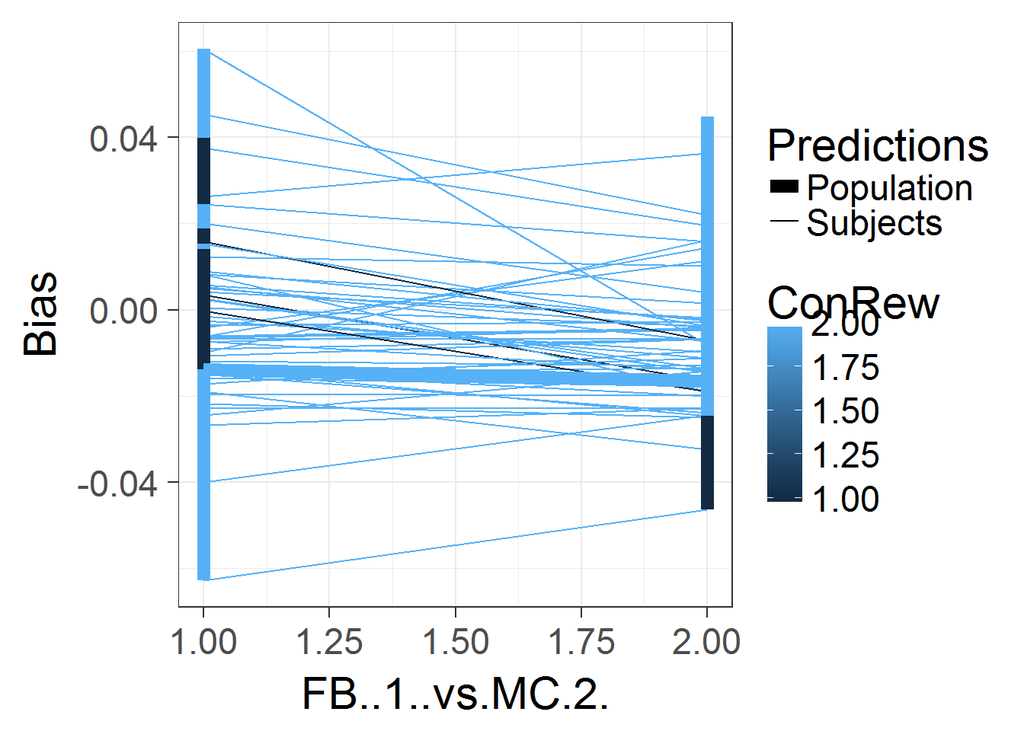

```r
library(ggplot2)

# faulty
p <- ggplot(simondata, aes(x=FB..1..vs.MC.2., y=Bias, colour=ConRew)) +
  geom_line(aes(y=predict(model4), group=Participant, size="Subjects")) +
  geom_line(data=simondata, aes(y=predict(model4, level=0, newdata=simondata), size="Population")) +
  scale_size_manual(name="Predictions", values=c("Subjects"=0.5, "Population"=3)) +
  theme_bw(base_size=22)
print(p)
```